# Fifty States Project

3/23/2022

## Data Source and Procedures

### Open Source Software & Publicly Available Data

- GSOM (Global Summary of Monthly Data)
- Analysis and Graphics R/Rstudio
- Selected Station with longest records and fewest missing data
- Select month had strongest trend
- Evaluate Monthly Temp. Max and Min for trends

## Weather Station Selected

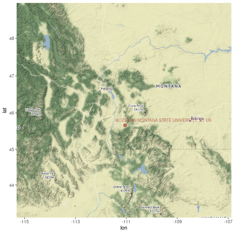

## Months with Largest Changes

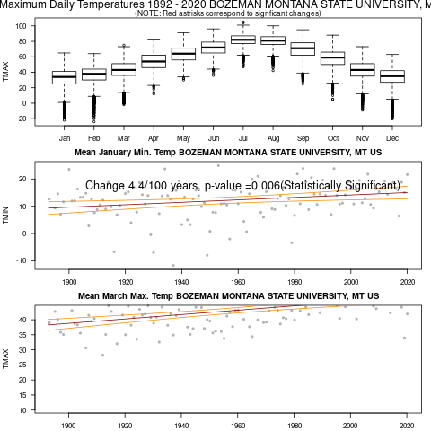

## Record Temperatures

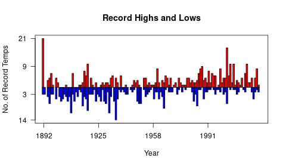

## Max. Temperature Anomaly Trend

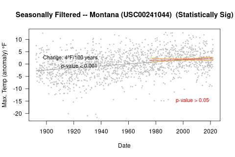

## Impacts

- Montana’s climate is changing.
- In the past century, most of the state has warmed about two degrees (F).
- Heat waves are becoming more common, and snow is melting earlier in spring.
- Rising temperatures and recent droughts have killed many trees by drying out soils, increasing the risk of forest fires, or enabling outbreaks of forest insects.
- In the coming decades, the changing climate is likely to decrease the availability of water in Montana, affect agricultural yields, and further increase the risk of wildfires.

[EPA Snapshot](https://19january2017snapshot.epa.gov/sites/production/files/2016-09/documents/climate-change-mt.pdf)

## State Adaptation / Mitigation Plans

- In 2019, Governor Steve Bullock issued Executive Order 8-2019, which established the Montana Climate Solutions Council (Council) and joined Montana to the U.S. Climate Alliance.
- The Executive Order directed the Council to develop the Montana Climate Solutions Plan.

[Source: Georgetown Climate Center] (https://www.georgetownclimate.org/adaptation/state-information/montana/overview.html)

## Next Steps

- Put ideas in comments how what other can do to support state efforts
- Be kind: Responding to climate change includes a complex array of ethical issues.
- “Be curious”, Ted Lasso.